# Proyecto Estadística

2023-07-07

## Objetivos

- Analizar las ciudades con mejor ranking de experiencia de Airbnb en Europa del 2023.
- Describir las características de los alojamientos más caros y más económicos en ciudades de Europa del 2023.
- Analizar la atracción de un Airbnb y su relación con su ubicación en ciudades de Europa del 2023.

## Algunas Variables del Estudio

Ciudad (Categórica nominal) Guest Satisfaction (Categórica ordinal)

Cuándo lo reservan (Categórica nominal) Person Capacity (Numérica discreta)

Superhost (Categórica nominal) Price (Numérica continua)

Multiple Rooms (Categórica nominal) City Center (km) (Numérica continua)

Cleanliness Rating (Categórica ordinal) Metro Distance (km) (Numérica continua)

Normalised attraction Index (Numérica continua)

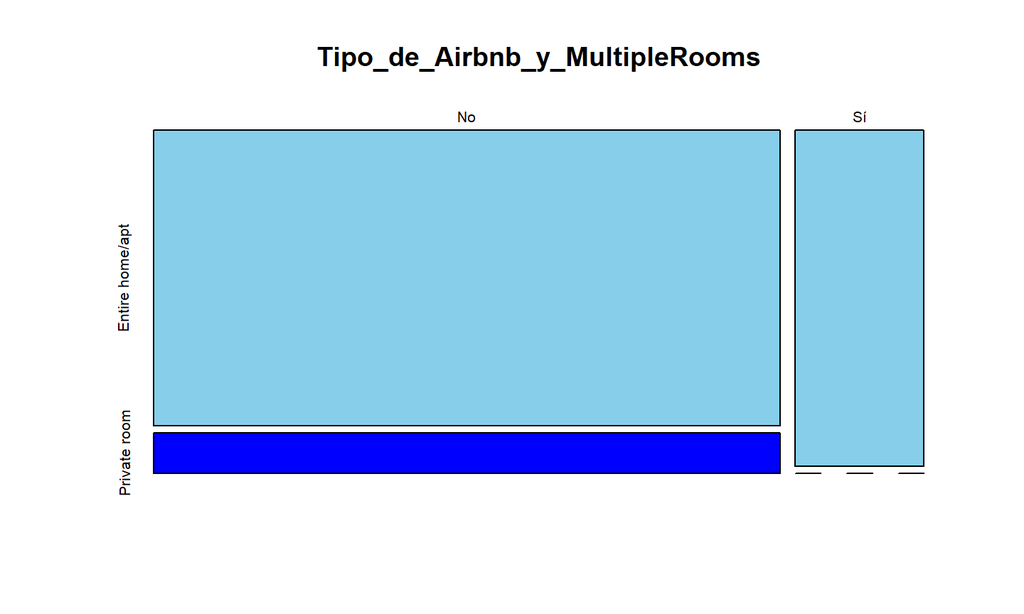

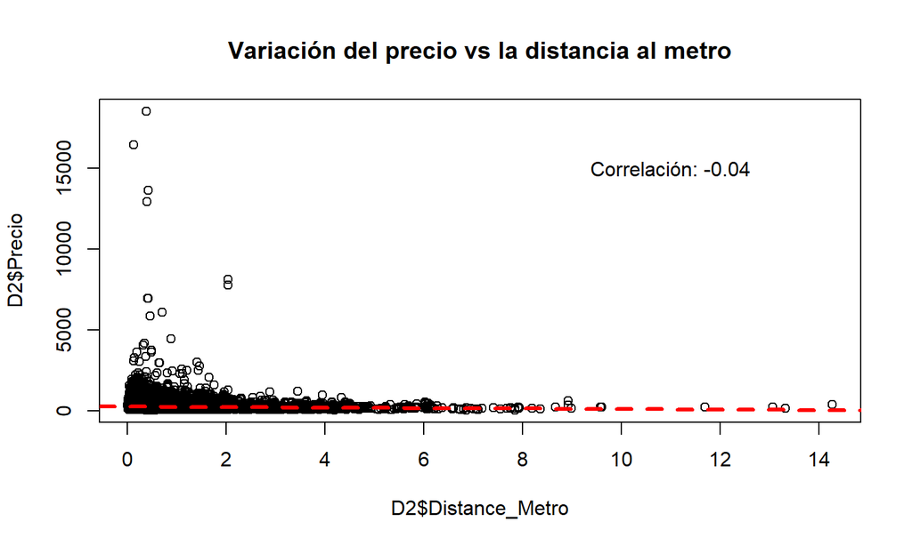

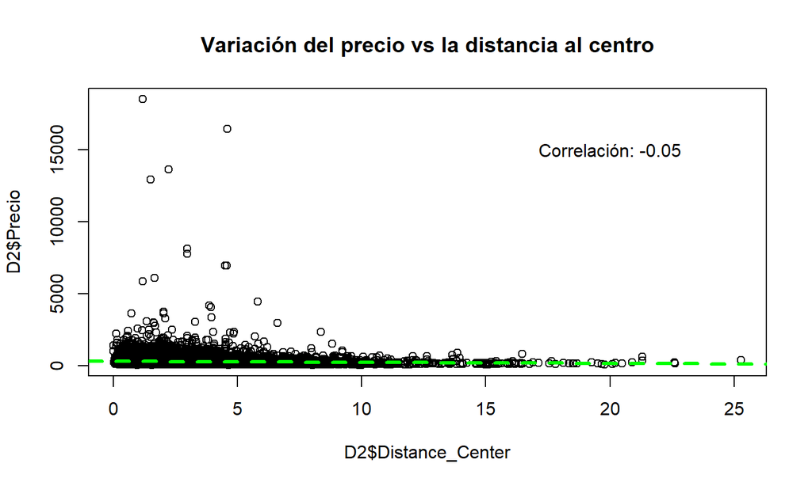

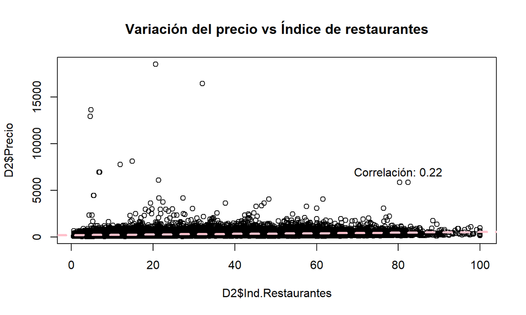

## Probabilidad empírica

Una de las variables para la cuál se cálculo la probabilidad empírica fue Ciudad.

```
##
##  Amsterdam     Athens  Barcelona     Berlin   Budapest
## 0.04986336 0.12657621 0.06791485 0.05954835 0.09641847
```

```
##
##     Lisbon      Paris       Rome     Vienna
## 0.13815506 0.16032987 0.21640217 0.08479168
```

Se puede observar que la probabilidad de seleccionar un airbnb ubicado en Roma es la mayor, mientras que la probabilidad de seleccionar uno que se encuentre en Amsterdam es la menor.

## Eventos dependientes e independientes

Para esta parte tuvimos que buscar, según nuestra base de datos, cuatro pares de eventos y fundamentar por qué dos de ellos son independientes y los otros dos, dependientes. Nos basamos en tres relaciones importantes:

\[P(B/A)=\frac{P(A/B).P(B)}{P(A)}\] \[P(B/A)=\frac{P(A∩B)}{P(A)}\] \[P(B∩A)=P(A).P(B)\]

Evento A: Una persona califica a una sede de Airbnb con un puntaje de 10 en limpieza.

Evento B: Una persona debe pagar un precio mayor al promedio del precio de Airbnb.

\(Promedio del precio: 260.0944\) \(ProbA=0.600326\) \(ProbB=0.3290023\) \(ProbB/A=0.3296861\) \(ProbAandB=0.1979192\)

Calculamos si son independientes o no: \(ProbAandB-ProbA*ProbB = 0\)

Usando el teorema de Bayes: \(ProbBresA = 0.33 y ProbB=0.33\) $ $ \(ProbAresB=0.6 y ProbA=0.6\)

Definamos los dos eventos:

A:Una persona escoge un Airbnb en el cual pague un precio mayor al precio promedio de todos los Airbnb’s.

B:Una persona puntúe el Airbnb con un puntaje de satisfacción mayor a 90.

\(ProbA=0.3290023 ProbB=0.741214 ProbAandB=0.242988 ProbBresA=0.7385602 ProbAresB=0.3278243\)

Calculamos si son independientes o no: \(ProbAandB-ProbA*ProbB = 0\)

Usando el teorema de Bayes: \(ProbBresA = 0.74 y ProbB=0.74\) $ $ \(ProbAresB=0.33 y ProbA=0.33\)

## Eventos dependientes

Definamos los dos eventos:

A: Una persona califique con un puntaje mayor a 9 respecto a Limpieza al Airbnb en el que se hospedó.

B: Una persona califica con un puntaje de satisfacción mayor a 90 al Airbnb en el que se hospedó.

Calculamos si son independientes o no: \(ProbAandB-ProbA*ProbB = 0.1\)

Definamos los dos eventos:

A: De todas las sedes en la que Airbnb tiene esparcido alrededor del mundo, este esté en la ciudad de Amsterdam

B: Una persona que se hospede en un hotel de Airbnb tenga que pagar un precio mayor al precio promedio de todo Airbnb.

Calculamos si son independientes o no: \(ProbAandB-ProbA*ProbB = 0.03\)

## Variables aleatorias discretas

Una de las variables aleatorias discretas que fue analizada fue la variable Satisfacción

\(X~Bin(p,n)\)

Donde: p es la probilidad del éxito E n es tamaño de la muestra

## Variables aleatorias discretas

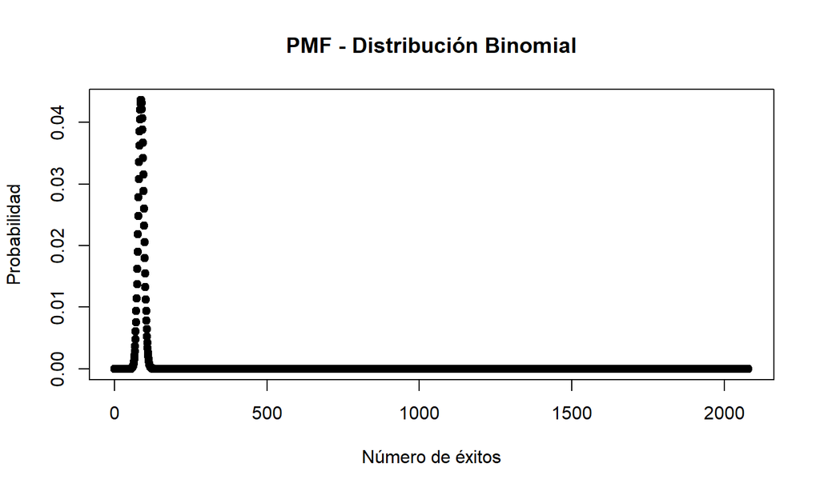

## Variables aleatorias continuas

- Una de las variables que se analizó para esta sección es la de “Distance_Center”. X es variable aleatoria que cuenta la cantidad de Airbnb que está a una distancia mayor o igual a 5km de su centro en Amsterdam.

```
## [1] 2.329951
```

- Para validar la normalidad de la variable, se comparan la media y la mediana:

```
## [1] 2.825052
```

```
## [1] 2.329951
```

## Variables aleatorias continuas

```
## [1] 2.825052
```

## Conclusiones

- El análisis estadístico de los airbnb’s del dataset se realizó aplicando los conceptos de probabilidad vistos en el curso. Se contó con un dataset bastante extenso, lo que permitió resultados bastante precisos.
- En este caso, no encontramos relaciones significativas entre el precio de un airbnb y alguna variable relacionada a su calidad (limpieza, satisfacción, indice de atracción).